# Natality by State, 2007-2016

Nassika Dabel | June 5, 2018

## Background

The topic for my project is natality. I am interested in learning if there is a correlation between the age and the education level of new mothers in the United States. Do women who pursue higher education wait longer to have children? The dataset is sourced from "Natality by State, 2007-2016". It includes the education, age, and race of mothers who gave birth as well as the birth weights of their newborns seperated by each state.

## Data

I am interested in seeing if there are correlations between the following variables a) the education level and the age of the mothers and b) the age of the mothers and their newborns' birth weights.

```python
import pandas as pd
import numpy as np
import matplotlib.pyplot as plt
import matplotlib.axes as ax
import statsmodels.formula.api as smf
%matplotlib inline
df = pd.read_csv("natality_2007_2016.csv")
print(df.describe())
print(pd.DataFrame.describe(df))
```

```
        State_Code  Education_Code        Births  Average_Birth_Weight  \
count  2115.000000     1966.000000   2115.000000           2115.000000
mean     28.496454        4.362665   1864.778251           3233.222799
std      15.637702        2.164297   5642.721592            133.124443
min       1.000000        1.000000     10.000000           2410.200000
25%      16.000000        3.000000     45.000000           3155.995000
50%      29.000000        4.000000    193.000000           3229.810000
75%      41.000000        6.000000   1087.000000           3322.285000
max      56.000000        8.000000  95429.000000           3876.000000

       Average_Age_of_Mother
count            2115.000000
mean               29.088435
std                 3.059544
min                20.660000
25%                26.880000
50%                29.330000
75%                31.360000
max                36.120000
        State_Code  Education_Code        Births  Average_Birth_Weight  \
count  2115.000000     1966.000000   2115.000000           2115.000000
mean     28.496454        4.362665   1864.778251           3233.222799
std      15.637702        2.164297   5642.721592            133.124443
min       1.000000        1.000000     10.000000           2410.200000
25%      16.000000        3.000000     45.000000           3155.995000
50%      29.000000        4.000000    193.000000           3229.810000
75%      41.000000        6.000000   1087.000000           3322.285000
max      56.000000        8.000000  95429.000000           3876.000000

       Average_Age_of_Mother
count            2115.000000
mean               29.088435
std                 3.059544
min                20.660000
25%                26.880000
50%                29.330000
75%                31.360000
max                36.120000
```

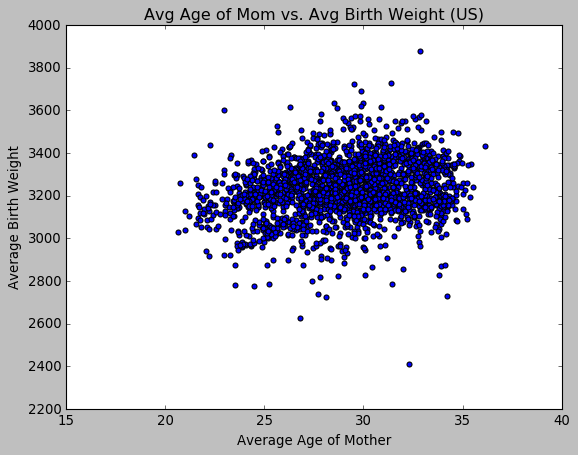

```python
births = df["Births"]
birth_weight= df["Average_Birth_Weight"]
age_mom = df["Average_Age_of_Mother"]
import matplotlib as mpl
import matplotlib.pyplot as plt
%matplotlib inline
plt.style.use("classic")
x = np.linspace(0,10,100)
fig1 = plt.figure()
plt.scatter(age_mom, birth_weight)
plt.title("Avg Age of Mom vs. Avg Birth Weight (US)")
plt.xlabel("Average Age of Mother")
plt.ylabel("Average Birth Weight")
plt.show()
fig1.savefig("fig1.png")
```

```python
df = df [["Average_Age_of_Mother", "Average_Birth_Weight"]].dropna()
df.head()
```

|  | Average_Age_of_Mother | Average_Birth_Weight |
| --- | --- | --- |
| 0 | 24.96 | 3049.36 |
| 1 | 24.69 | 3144.98 |
| 2 | 26.06 | 3209.97 |
| 3 | 28.33 | 3431.08 |
| 4 | 30.64 | 3366.45 |

```python
model = smf.ols(formula="np.log(Average_Birth_Weight) ~ Average_Age_of_Mother", data=df)
est = model.fit()
est.summary()
```

OLS Regression Results

| Dep. Variable: | np.log(Average_Birth_Weight) | R-squared: | 0.044 |
| --- | --- | --- | --- |
| Model: | OLS | Adj. R-squared: | 0.044 |
| Method: | Least Squares | F-statistic: | 98.38 |
| Date: | Sat, 16 Jun 2018 | Prob (F-statistic): | 1.07e-22 |
| Time: | 15:21:56 | Log-Likelihood: | 3777.6 |
| No. Observations: | 2115 | AIC: | -7551. |
| Df Residuals: | 2113 | BIC: | -7540. |
| Df Model: | 1 |  |  |
| Covariance Type: | nonrobust |  |  |

|  | coef | std err | t | P>\|t\| | [0.025 | 0.975] |
| --- | --- | --- | --- | --- | --- | --- |
| Intercept | 7.9972 | 0.008 | 947.902 | 0.000 | 7.981 | 8.014 |
| Average_Age_of_Mother | 0.0029 | 0.000 | 9.919 | 0.000 | 0.002 | 0.003 |

| Omnibus: | 201.672 | Durbin-Watson: | 1.148 |
| --- | --- | --- | --- |
| Prob(Omnibus): | 0.000 | Jarque-Bera (JB): | 628.473 |
| Skew: | -0.479 | Prob(JB): | 3.38e-137 |
| Kurtosis: | 5.493 | Cond. No. | 280. |

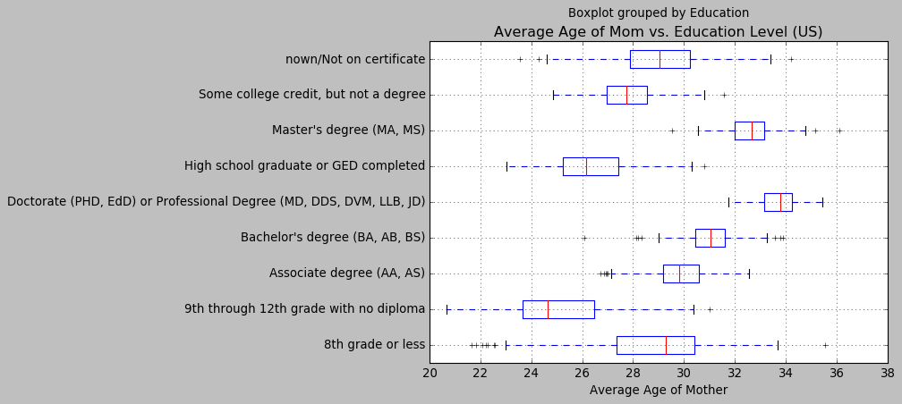

```python
df = pd.read_csv("natality_2007_2016.csv")
education_lev = df["Education"]
age_mom = df["Average_Age_of_Mother"]
#print(type(education_lev))

edu_age = df.loc[:,["Education", "Average_Age_of_Mother"]]
#print(edu_age.head())
#print(type(edu_age))
fig3 = plt.figure()
#plt.scatter(age_mom, education_lev)

edu_age.boxplot(vert=False, by='Education')

plt.title("Average Age of Mom vs. Education Level (US)")
plt.xlabel("Average Age of Mother")

plt.show()
fig3.savefig("fig3.png")
```

## Analysis

The second hypothesis I would like to test is if the age of a mother has any affect on their babies' birth weight? The null hypothesis would be that there is no correlation between the mother's age and baby's birth weights. The alternative hypothesis would be that older mother's newborn birth weights were lower than that of younger mothers and vice versa.

```python
# Hypothesis testing - difference of means

# High school diploma completed
age_hs_mean =  26
age_hs_sd = np.sqrt(3.1)
age_hs_n = 284

# Master's degree completed
age_ms_mean =  33
age_ms_sd = np.sqrt(2.2)
age_ms_n = 222
sample_age_hs = np.random.normal(loc=age_hs_mean, scale=age_hs_sd, size=age_hs_n)
print("Age (High School Diploma)")
print("Observations:", len(sample_age_hs))
print("Mean:", np.mean(sample_age_hs))
print("Standard Deviation", np.std(sample_age_hs))
print("Variance", np.std(sample_age_hs)**2)
print("")
sample_age_ms = np.random.normal(loc=age_ms_mean, scale=age_ms_sd, size=age_ms_n)
print("Age (Master's Degree)")
print("Observations:", len(sample_age_ms))
print("Mean:", np.mean(sample_age_ms))
print("")
print("Standard Deviation", np.std(sample_age_ms))
print("Variance", np.std(sample_age_ms)**2)
obs_diff = age_hs_mean - age_ms_mean
exp_diff = 0
var_hs = (age_hs_sd**2) / age_hs_n
var_ms = (age_ms_sd**2) / age_ms_n
std_err = np.sqrt(var_hs + var_ms)
print("Sample difference:", obs_diff)
print("Expected population difference:", exp_diff)
print("Standard Error:", std_err)
Z = (obs_diff - exp_diff) / std_err
print("")
print("Z-score:", Z)
```

```
Age (High School Diploma)
Observations: 284
Mean: 26.1482978011
Standard Deviation 1.74095292643
Variance 3.03091709206

Age (Master's Degree)
Observations: 222
Mean: 32.8716839635

Standard Deviation 1.6573605576
Variance 2.7468440179
Sample difference: -7
Expected population difference: 0
Standard Error: 0.144310092744

Z-score: -48.5066558196
```

## Conclusion

After analyzing the data generated by my first hypothesis, I found that for this set of data the education level and the age of the mothers did show a correlation. Mothers who pursued a higher education were older than mothers with less education. The "8th grade or less" education category deviated from my hypothesis in that mothers who pursued higher education were older, seeing as that category produced an older age range than the "9th through 12th grade with no diploma" category.

The most challenging aspect of working with this dataset was having a lot of non-numeric variables and coming up with the best potentially meaningful hypothesis questions to pose from them based on the numeric variables provided. Only one of my hypotheses produced a plot that I could discern any actual meaning from.